```python
import pandas as pd

train = pd.read_csv('train.csv')
train.info()
```

```
<class 'pandas.core.frame.DataFrame'>
RangeIndex: 42180 entries, 0 to 42179
Data columns (total 16 columns):
 #   Column     Non-Null Count  Dtype
---  ------     --------------  -----
 0   age        42180 non-null  int64
 1   job        42180 non-null  object
 2   marital    42180 non-null  object
 3   education  42178 non-null  object
 4   default    42180 non-null  object
 5   balance    42175 non-null  float64
 6   housing    42177 non-null  object
 7   loan       42179 non-null  object
 8   contact    42173 non-null  object
 9   day        42180 non-null  int64
 10  month      42180 non-null  object
 11  duration   42169 non-null  float64
 12  campaign   42180 non-null  int64
 13  previous   42180 non-null  int64
 14  poutcome   42180 non-null  object
 15  class      42180 non-null  object
dtypes: float64(2), int64(4), object(10)
memory usage: 5.1+ MB
```

בקובץ האימון שלנו יש 6 עמודות שהן לא מלאות כלומר יש בהם מקומות ריקים ו10 עמודות מלאות שבשום שורה לא חסר ערך כלשהו

```python
missing_data = pd.DataFrame({'total_missing': train.isnull().sum(), 'perc_missing': (train.isnull().sum()/82790)*100})
missing_data
```

|  | total_missing | perc_missing |
| --- | --- | --- |
| age | 0 | 0.000000 |
| job | 0 | 0.000000 |
| marital | 0 | 0.000000 |
| education | 2 | 0.002416 |
| default | 0 | 0.000000 |
| balance | 5 | 0.006039 |
| housing | 3 | 0.003624 |
| loan | 1 | 0.001208 |
| contact | 7 | 0.008455 |
| day | 0 | 0.000000 |
| month | 0 | 0.000000 |
| duration | 11 | 0.013287 |
| campaign | 0 | 0.000000 |
| previous | 0 | 0.000000 |
| poutcome | 0 | 0.000000 |
| class | 0 | 0.000000 |

```python
train.describe()
```

|  | age | balance | day | duration | campaign | previous |
| --- | --- | --- | --- | --- | --- | --- |
| count | 42180.000000 | 42175.000000 | 42180.000000 | 42169.000000 | 42180.000000 | 42180.000000 |
| mean | 40.739379 | 1321.708880 | 15.864391 | 255.429273 | 2.824941 | 0.450403 |
| std | 10.097570 | 2984.706622 | 8.303157 | 258.178684 | 3.175839 | 2.143422 |
| min | 18.000000 | -8019.000000 | 1.000000 | 0.000000 | 1.000000 | 0.000000 |
| 25% | 33.000000 | 61.000000 | 8.000000 | 101.000000 | 1.000000 | 0.000000 |
| 50% | 39.000000 | 425.000000 | 16.000000 | 176.000000 | 2.000000 | 0.000000 |
| 75% | 48.000000 | 1369.500000 | 21.000000 | 314.000000 | 3.000000 | 0.000000 |
| max | 95.000000 | 102127.000000 | 31.000000 | 4918.000000 | 63.000000 | 275.000000 |

אפשר לראות כי רוב היתרה היא בין 61 ל-1369.5 אך התווך כולו הוא בין -8019 ל-102127 ניתן לראות כי רוב הגילאים הם בין 33 ל 48 למרות שהתווך הכללי הוא בין 18 ל95

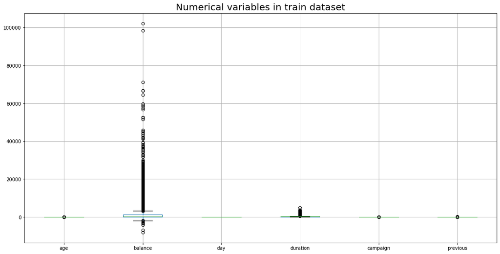

```python
import matplotlib.pyplot as plt
num_cols = ['age', 'balance', 'day', 'duration', 'campaign', 'previous']
plt.figure(figsize=(18,9))
train[num_cols].boxplot()
plt.title("Numerical variables in train dataset", fontsize=20)
plt.show()
```

מגרף זה ניתן לראות את החריגים בצורה טובה יותר

```python
train.sort_values(by=['duration'], ascending=False).head(10)
```

|  | age | job | marital | education | default | balance | housing | loan | contact | day | month | duration | campaign | previous | poutcome | class |
| --- | --- | --- | --- | --- | --- | --- | --- | --- | --- | --- | --- | --- | --- | --- | --- | --- |
| 24148 | 59 | technician | married | tertiary | no | 6573.0 | yes | no | telephone | 10 | nov | 4918.0 | 1 | 0 | unknown | no |
| 9947 | 59 | management | married | secondary | no | 1321.0 | no | no | unknown | 9 | jun | 3881.0 | 3 | 0 | unknown | yes |
| 19639 | 37 | blue-collar | married | tertiary | no | 359.0 | no | yes | cellular | 7 | aug | 3422.0 | 2 | 0 | unknown | no |
| 2386 | 45 | blue-collar | married | secondary | no | 66.0 | yes | no | unknown | 13 | may | 3366.0 | 3 | 0 | unknown | no |
| 21113 | 43 | self-employed | married | tertiary | no | 423.0 | no | no | cellular | 14 | aug | 3322.0 | 2 | 0 | unknown | no |
| 24095 | 30 | admin. | married | secondary | no | 1310.0 | no | no | telephone | 27 | oct | 3284.0 | 1 | 0 | unknown | no |
| 24044 | 36 | self-employed | single | tertiary | no | -103.0 | yes | yes | telephone | 17 | oct | 3253.0 | 1 | 0 | unknown | yes |
| 12347 | 28 | admin. | single | secondary | no | -7.0 | no | yes | unknown | 26 | jun | 3183.0 | 2 | 0 | unknown | yes |
| 30747 | 53 | admin. | married | secondary | no | 849.0 | yes | no | cellular | 6 | feb | 3102.0 | 3 | 0 | unknown | yes |
| 6451 | 44 | services | divorced | secondary | no | 51.0 | yes | yes | unknown | 27 | may | 3094.0 | 2 | 0 | unknown | yes |

```python
train.sort_values(by=['balance'], ascending=False).head(10)
```

|  | age | job | marital | education | default | balance | housing | loan | contact | day | month | duration | campaign | previous | poutcome | class |
| --- | --- | --- | --- | --- | --- | --- | --- | --- | --- | --- | --- | --- | --- | --- | --- | --- |
| 39989 | 51 | management | single | tertiary | no | 102127.0 | no | no | cellular | 3 | jun | 90.0 | 1 | 0 | unknown | no |
| 26227 | 59 | management | married | tertiary | no | 98417.0 | no | no | telephone | 20 | nov | 145.0 | 5 | 0 | unknown | no |
| 41693 | 60 | retired | married | primary | no | 71188.0 | no | no | cellular | 6 | oct | 205.0 | 1 | 0 | unknown | no |
| 19785 | 56 | management | divorced | tertiary | no | 66721.0 | no | no | cellular | 8 | aug | 442.0 | 2 | 0 | unknown | no |
| 21192 | 52 | blue-collar | married | primary | no | 66653.0 | no | no | cellular | 14 | aug | 109.0 | 3 | 0 | unknown | no |
| 19420 | 59 | admin. | married | unknown | no | 64343.0 | no | no | cellular | 6 | aug | 45.0 | 4 | 0 | unknown | no |
| 41374 | 32 | entrepreneur | single | tertiary | no | 59649.0 | no | no | cellular | 1 | sep | 69.0 | 2 | 0 | unknown | no |
| 12926 | 56 | blue-collar | married | secondary | no | 58932.0 | no | no | telephone | 7 | jul | 339.0 | 2 | 0 | unknown | no |
| 920 | 44 | admin. | married | secondary | no | 58544.0 | yes | no | unknown | 7 | may | 144.0 | 2 | 0 | unknown | no |
| 27390 | 50 | services | married | secondary | no | 57435.0 | yes | no | cellular | 21 | nov | 319.0 | 3 | 0 | unknown | no |

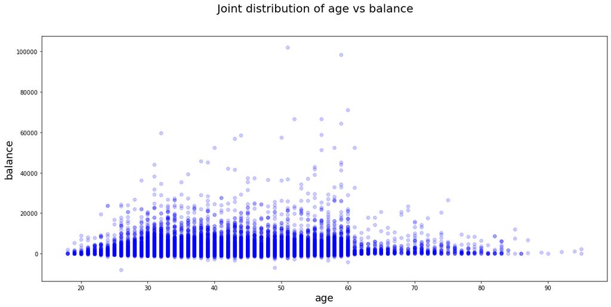

```python
plt.figure(figsize=(18,8))
plt.xlabel("age", fontsize=18)
plt.ylabel("balance", fontsize=18)
plt.suptitle("Joint distribution of age vs balance", fontsize= 20)
plt.plot(train.age, train['balance'], 'bo', alpha=0.2)
plt.show()
```

אפשר לראות סטייה משמעותית מיתרה לגיל: האנשים העניים ביותר הם הצעירים והזקנים ביותר אנו יכולים לצפות כי חריגות לכאורה בגילאים ינהגו באופן דומה

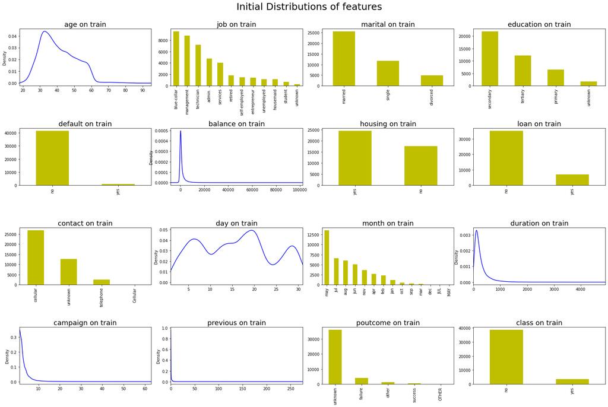

```python
def plot_dist(col, ax):
    if col not in ['age', 'balance', 'day','duration','campaign', 'previous']:
        train[col].value_counts().plot(kind='bar', facecolor='y', ax=ax)
    else:
        train[col].plot(kind='density', ax=ax, bw_method = 0.15, color='b', xlim=(train[col].min(), train[col].max()))
    ax.set_title("{} on train".format(col), fontsize= 18)
    return ax

f, ax = plt.subplots(4,4, figsize = (22,15))
f.tight_layout(h_pad=9, w_pad=2, rect=[0, 0.03, 1, 0.93])
cols = train.columns
k = 0
for i in range(4):
    for j in range(4):
        plot_dist(cols[k], ax[i][j])
        k += 1
__ = plt.suptitle("Initial Distributions of features", fontsize= 25)
```

העמודה "קמפיין" אומנם נראית רציפה בתווך 0 עד 60 אך כמעט כל הערכים הם בין 0 ל- 10 לכן יהיה נכון להפוך אותה לעמודה קטגוריאלית כנל לגבי הערכים של העמודה"קודם" אשר נראת כעמודה רציפה בין 0 למעל 250 אך כמעט כל הערכים קטנים מ10 לכן יהיה אפשרי להפוך אותה לקטגוריאלית

```python
clean = pd.read_csv("train_clean.csv")
clean.info()
```

```
<class 'pandas.core.frame.DataFrame'>
RangeIndex: 42180 entries, 0 to 42179
Data columns (total 16 columns):
 #   Column     Non-Null Count  Dtype
---  ------     --------------  -----
 0   age        42180 non-null  int64
 1   job        42180 non-null  int64
 2   marital    42180 non-null  int64
 3   education  42180 non-null  int64
 4   default    42180 non-null  int64
 5   balance    42180 non-null  int64
 6   housing    42180 non-null  int64
 7   loan       42180 non-null  int64
 8   contact    42180 non-null  int64
 9   day        42180 non-null  int64
 10  month      42180 non-null  int64
 11  duration   42180 non-null  int64
 12  campaign   42180 non-null  int64
 13  previous   42180 non-null  int64
 14  poutcome   42180 non-null  int64
 15  class      42180 non-null  int64
dtypes: int64(16)
memory usage: 5.1 MB
```

אנו יכולים לראות שעכשיו אין עוד ערכים חסרים! אנו יכולים לעבור להדמיה ולקבל יותר תובנה לגבי הנתונים

```
Index(['age', 'job', 'marital', 'education', 'default', 'balance', 'housing',
       'loan', 'contact', 'day', 'month', 'duration', 'campaign', 'previous',
       'poutcome', 'class'],
      dtype='object')
```

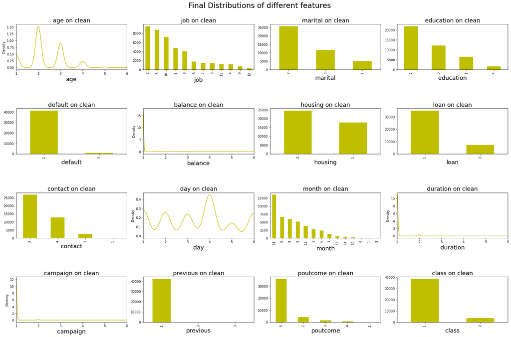

```python
print(clean.columns)
def plot_dist(col, ax):
    if col not in ['age', 'balance', 'day','duration','campaign']:
        clean[col].value_counts().plot(kind='bar', facecolor='y', ax=ax)
    else:
        clean[col].plot(kind='density', ax=ax, bw_method = 0.15, color='y', xlim=(clean[col].min(), clean[col].max()))
    ax.set_xlabel('{}'.format(col), fontsize=18)
    ax.set_title("{} on clean".format(col), fontsize= 18)
    return ax

f, ax = plt.subplots(4,4, figsize = (22,15))
f.tight_layout(h_pad=10, w_pad=2, rect=[0, 0.03, 1, 0.93])
cols = clean.columns
k = 0
for i in range(4):
    for j in range(4):
        plot_dist(cols[k], ax[i][j])
        k += 1
__ = plt.suptitle("Final Distributions of different features", fontsize= 23)
```

```python
def plot_barh(df,col, cmap = None, stacked=False, norm = None):
    df.plot(kind='barh', colormap=cmap, stacked=stacked)
    fig = plt.gcf()
    fig.set_size_inches(24,12)
    plt.title("job vs {}-feedback -  train {}".format(col, '(Normalized)' if norm else ''), fontsize= 20)
    plt.ylabel('job', fontsize = 18)
    plot = plt.xlabel('Frequency', fontsize=18)

def norm_counts(t):
    norms = np.linalg.norm(t.fillna(0), axis=1)
    t_norm = t[0:0]
    for row, euc in zip(t.iterrows(), norms):
        t_norm.loc[row[0]] = list(map(lambda x: x/euc, list(row[1])))
    return t_norm
```

```python
clean.job.value_counts()
```

```
2     9509
5     8748
10    7159
1     4758
8     4008
6     1789
7     1483
3     1445
11    1175
4     1166
9      679
12     261
Name: job, dtype: int64
```

```python
clean.age.value_counts()
```

```
2    20343
3    12134
1     6312
4     3106
5      254
6       31
Name: age, dtype: int64
```

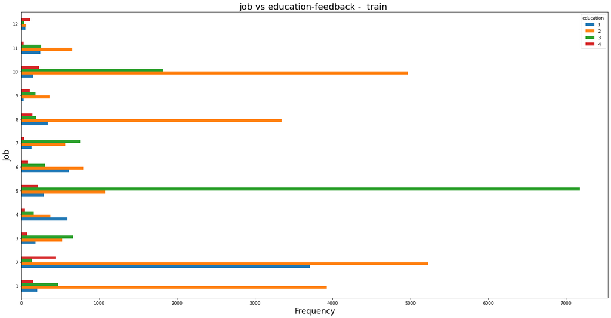

```python
import numpy as np
g_by_category = clean.groupby('job')
cat_fit = g_by_category['education'].value_counts()
cat_fit = cat_fit.unstack()
cat_fit_norm = norm_counts(cat_fit)
#cat_fit_norm.drop(['education'], axis=1, inplace=True)
plot_barh(cat_fit, 'education')
```

ניתן לראות כי יש קבוצות שההתאמה בהם היא גבוה מאוד וקבוצות עם התאמה מועטה

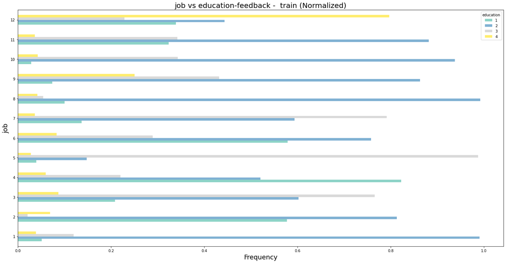

```python
plot_barh(cat_fit_norm, 'education', norm=1, cmap='Set3')
```

העלילה המנורמלת, תוך התמקדות בבעיות, מאפשרת לנו להתעמק בסיבות השיבה מבחינת אורך לקטגוריה:

אפשר לראות כי אנשים שחונכו ב-2 הם כמות האנשים הגדולה במעבודות1,2,6,8,9,10,11 ואנשים אשר חונכו ב-3 הם הרוב בעבודות 3,5,7 ואנשים שחוכנו ב-1 וב-4 הם רוב רק במקומות 4 ו12 בהתאמה

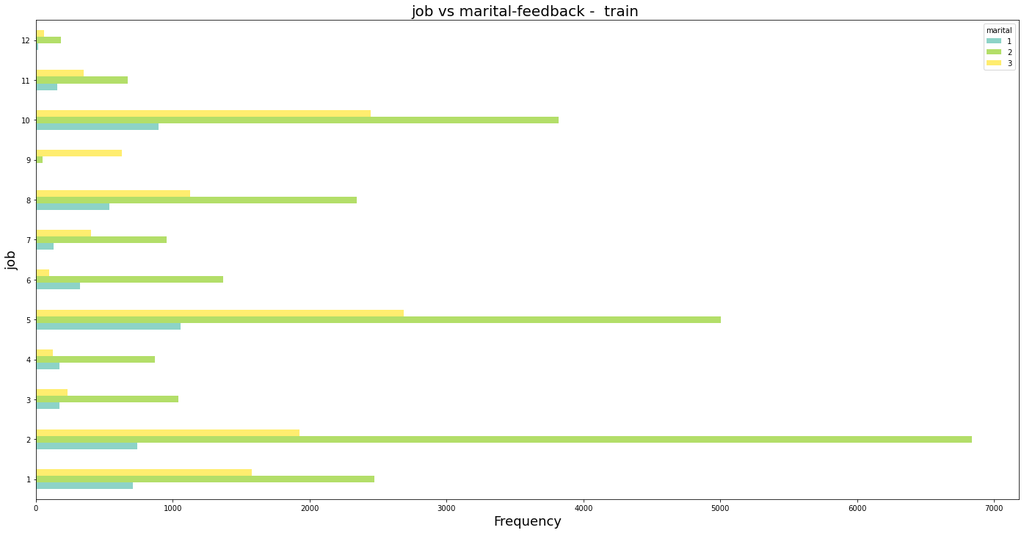

```python
cat_len = g_by_category['marital'].value_counts()
cat_len = cat_len.unstack()
plot_barh(cat_len, 'marital', 'Set3')
```

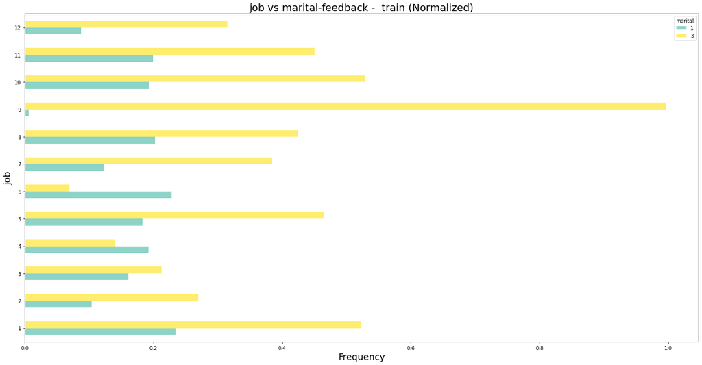

```python
cat_len_norm = norm_counts(cat_len)
cat_len_norm.drop([2], axis = 1, inplace=True)
plot_barh(cat_len_norm, 'marital', cmap='Set3', norm=1)
```

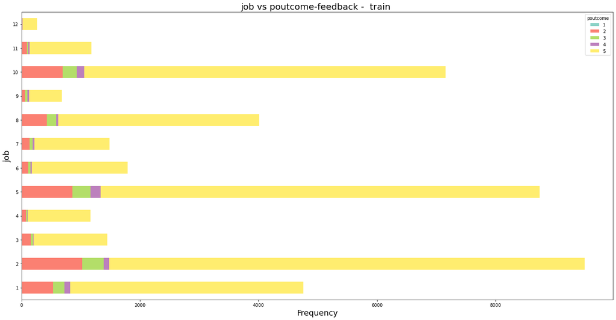

```python
cat_quality = g_by_category['poutcome'].value_counts()
cat_quality = cat_quality.unstack()
plot_barh(cat_quality, 'poutcome', 'Set3', stacked=1)
```

אפשר לראות כי הרוב השולט הגיע למצב 5 בעבודה

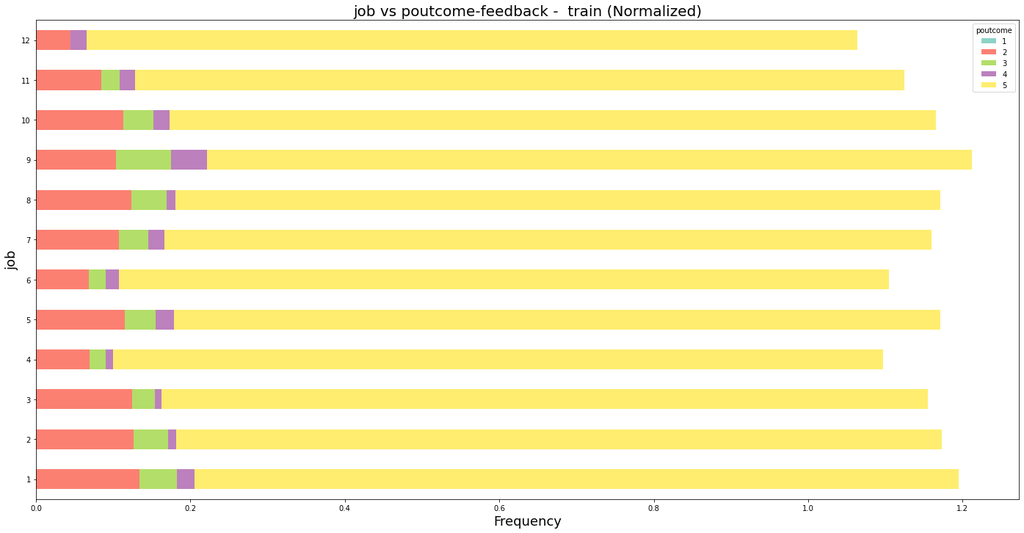

```python
cat_quality_norm = norm_counts(cat_quality)
#cat_quality_norm.drop(['unknown'], axis = 1, inplace=True)
plot_barh(cat_quality_norm, 'poutcome', 'Set3', stacked=1, norm=1)
```

אפשר לראות כי לאחר הנורמליזציה מצב 2 גדל והפך בערך לשווה בכל העמודות אבל מצב 5 גדל משמעותית ועדין הוא המצב הגדול ביותר בכלל העבודות

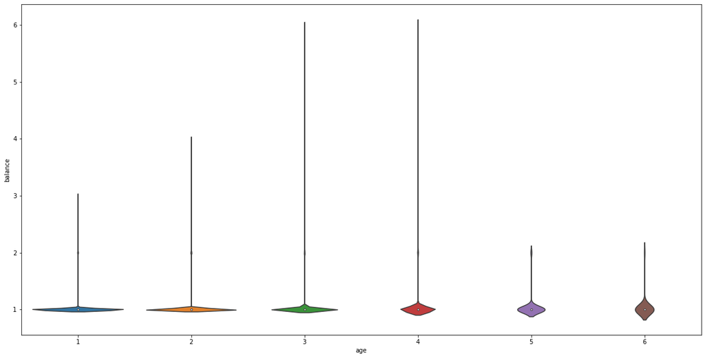

```python
import seaborn as sns
fig = plt.gcf()
fig.set_size_inches(20,10)
__ = sns.violinplot(x='age', y='balance',data=clean, size = 20)
```

[output not shown]

[figure not shown]

```python
from sklearn.metrics import confusion_matrix, ConfusionMatrixDisplay

df = pd.read_csv("C:/Users/haimr/proj/predictions/nonorm_ed_nb.csv")

y_true = df["class"]
y_preds = df["prediction"]
classes = y_true.unique()
mtx = confusion_matrix(y_true, y_preds, labels=classes)
print("naive bayes algorithm,normalization, equal depth dics ")
ConfusionMatrixDisplay(mtx, display_labels=classes).plot(cmap=plt.cm.Blues)
fig.subplots_adjust(hspace=0.40)
```

[figure not shown]

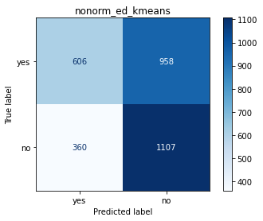

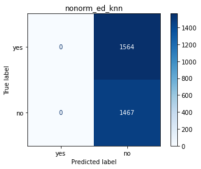

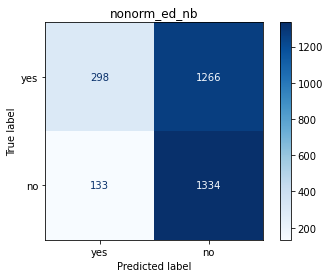

[figure not shown]

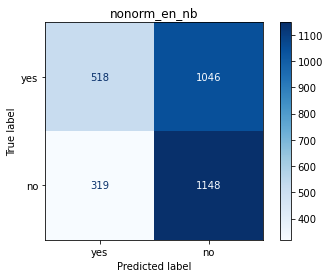

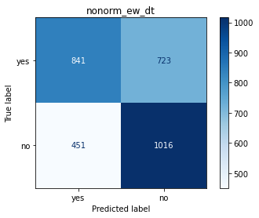

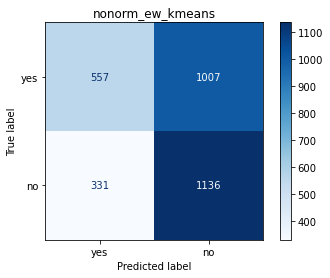

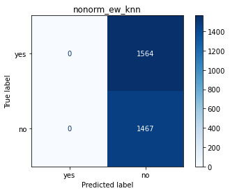

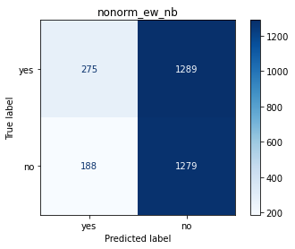

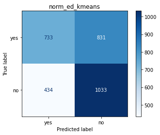

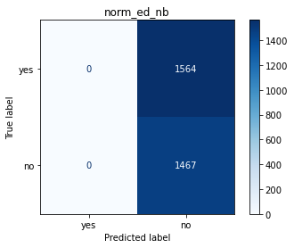

[4 more figures not shown]

```python
import pandas as pd
import os
import glob

path = "C:/Users/haimr/proj/predictions/"
csv_files = glob.glob(os.path.join(path, "*.csv"))

# loop over the list of csv files
for f in csv_files:
    x=f.split("_")[0]
    if (x.split('\\')[-1]) != "train":
        df = pd.read_csv(f)
        y_true = df["class"]
        y_preds = df["prediction"]
        classes = y_true.unique()
        mtx = confusion_matrix(y_true, y_preds, labels=classes, )
        plt.title((f.split("\\")[-1]).split(".")[0])
        ConfusionMatrixDisplay(mtx, display_labels=classes).plot(cmap=plt.cm.Blues)
        fig.subplots_adjust(hspace=0.40)
```